# 利吉粮食整理

利吉是什么呢？那就是利威尔和吉克的cp名字。大吉大利明明这么好磕，为什么每天都这么饿呢？小编也想知道，下面就让我们来看一下吧！

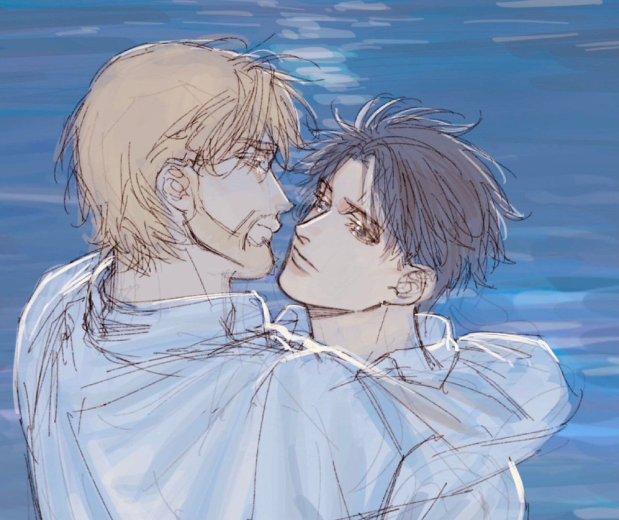

头图来源感谢Grifter老师

## 视频

b站视频的一些整理，有些是鬼畜？鬼畜就不能磕了吗？同框即是粮，砍猴就是上床！

[Levi vs Beast Titan](https://www.bilibili.com/video/BV1SK4y1N7fN)

[兵长诱惑器1.0](https://www.bilibili.com/video/BV1yf4y1e7Y7)

[兵长诱惑器2.0](https://www.bilibili.com/video/BV1Fy4y1S7NV)

[兵长诱惑器3.0](https://www.bilibili.com/video/BV18U4y1W7a3)

微信8.0

[下一个就是你了，利威尔](https://www.bilibili.com/video/BV1iv4y1Z7m7)

[漂洋过海来砍猴](https://www.bilibili.com/video/BV13y4y1b758)

[【进巨手书/艾莱】你这婆娘没良心](https://www.bilibili.com/video/BV1SB4y1A7gT)

[【利威尔X吉克｜love me like you do】因为我想细细品尝](https://www.bilibili.com/video/BV1ep4y1p7V4)

[兵长来吉克店里买片〖手书〗](https://www.bilibili.com/video/BV1VZ4y1c7tq)

[【巨人/沙雕手书】帕 岛 新 说 唱〗](https://www.bilibili.com/video/BV1B5411P7DR)

[【手绘动画】巨人最终季 第六、七集砍猴删减片段（演猿的幕后）](https://www.bilibili.com/video/BV1bU4y147mu)

[食物争夺战：兵长VS吉克](https://www.bilibili.com/video/BV1g54y1V74h)

## 图

直接放画手老师们的主页链接了，自行…

[Grifter](https://twitter.com/GrifterGirfus)

[Sufrig](https://twitter.com/Emis0416)

[玄戈又迟到了吗](https://twitter.com/HeatherHandsome)

[ZEKEzookzookZEKE🙈⚾️](https://twitter.com/Zeke_Fucker)

[ブビまる](https://twitter.com/bubiomaru)

[サーモンジェダイ🐟](https://twitter.com/Hayon_ero)

[Rat](https://twitter.com/RATsays_squeak/media)

## 文章

实际一看也不少嘛

[《冤家》](https://archiveofourown.org/works/28211919)

[《Do you want me?》](https://archiveofourown.org/works/28480335)

[《利威尔和他的三个金发美妞老婆（上）》(open relationship,涉及利文吉明cp)](https://archiveofourown.org/works/29241303)

[《利威尔和他的三个金发美妞老婆（下）》](https://archiveofourown.org/works/29558085)

[《淫妻（上）》（微量艾莱)](https://archiveofourown.org/works/29332662)

[《淫妻（中）》](https://archiveofourown.org/works/29374851)

[《淫妻（下）》](https://archiveofourown.org/works/29801088)

[《いい天気じゃないか》](https://archiveofourown.org/works/29430300)

[《巨木森林》](https://archiveofourown.org/works/29719707)

[《Roomie》](https://archiveofourown.org/works/30247728)

[《【利吉】 我对他恐惧至极》](https://loki2895.lofter.com/post/201dab11_1cb82b0f5)

[《爸妈今晚不在家》](https://gostraightout.lofter.com/post/1f0a7127_1cb90bb03)

[《一千零一夜》](https://invaneyurin.lofter.com/post/1ec57935_1cb8220a7)

[《我们结婚吧（上）》](https://kankankeke51900.lofter.com/post/4b6e3ec3_1cab7ddfb)

[《我们结婚吧（中）》](https://kankankeke51900.lofter.com/post/4b6e3ec3_1cab8b418)

[《我们结婚吧（下）》](https://kankankeke51900.lofter.com/post/4b6e3ec3_1cab8942d)

[《没剃须，捡到的也不是男高中生）》](https://archiveofourown.org/works/31043096)

[《两端》](https://archiveofourown.org/works/31107269/chapters/76858238)

[《到底谁是爸爸》](https://archiveofourown.org/works/30674411/chapters/75685403)

[《Hey Mr. Cleaner》](https://archiveofourown.org/works/31586690)

[《烂苹果》](https://archiveofourown.org/works/31187702)

[《不xx就出不去的房间》](https://share.api.weibo.cn/share/225668985.html?weibo_id=4639100873999485)

[《No light（0）》](https://share.api.weibo.cn/share/225671254.html?weibo_id=4609027106145344)

[《No light（1）》](https://share.api.weibo.cn/share/225671208.html?weibo_id=4609176245899009)

[《No light（2）》](https://share.api.weibo.cn/share/225671785.html?weibo_id=4622268762950633)

[《No light（3）》](https://share.api.weibo.cn/share/225670733.html?weibo_id=4622268762950633)

[《No light（4）》](https://share.api.weibo.cn/share/225670468.html?weibo_id=4627327604493884)

[《特殊的日子》](https://share.api.weibo.cn/share/225670163.html?weibo_id=4640715739759667)

[《暴食》](https://share.api.weibo.cn/share/225669984.html?weibo_id=4641903008025837)

[《沉迷》](https://share.api.weibo.cn/share/225670955.html?weibo_id=4611786629972074)

[《妥协》](https://share.api.weibo.cn/share/225671573.html?weibo_id=4614785918308605)

[《售后服务》](https://archiveofourown.org/works/30610580)

[《利威尔*吉克 pwp》](https://archiveofourown.org/works/28739382)